# Proof of concept Field Experiment

This is code migrated over from TwisterPCA.R and tidied up

```r
setwd("~/Google Drive/R Code/Twister Data")
#setwd("/Users/escott03/Google Drive/R Code/Twister Data")
library(reshape2)
library(dplyr)
library(ggplot2)
library(readr)
#library(xlsx)
library(readxl)
library(car)
#library(scales)
#library(MASS)
library(RColorBrewer)
library(venn)
source("~/Google Drive/R Code/myfunctions.R")
```

read in data (updated to Field2.xlsx on Mar 30, 2017)

```r
#twister <- read_csv("Field.csv")
twister <- read_excel("Field2.xlsx", sheet = 3)
twister1 <- twister[1:149, 1:12]
twister1[is.na(twister1)] = 0 #missing cells represent undetected compounds
twist2 = recast(twister1, variable ~ Compound, measure.var = c(2:12)) #this transposes the data so each column is a compound, but it re-orders the columns, which I don't like.
twist2
```

| variable | (2E)-Hexenal | (2E)-Hexenyl benzoate | (2E)-Pentenal | (3Z)-Hexenol | (3Z)-Hexenyl acetate | (3Z)-Hexenyl hexenoate | (3Z)-Octene | (E,E)-α-Farnesene | (E)-Caryophyllene | (E)-Herboxide | (Z)-Herboxide | (Z)-Jasmone | (Z)-Methyl jasmonate | 1-ethyl-2-methyl-Benzene | 1-ethyl-3-methyl-Benzene | 1-ethyl-4-methyl-Benzene | 1-methyl-2-Pyrrolidinone | 1-Methylisoquinoline | 1-Methylnaphthalene | 1-Octen-3-ol | 1-Octen-3-one | 1,2,4-Trimethylbenzene | 1,3-Dimethylnaphthalene | 1,4-Dimethylnaphthalene | 1(3H)-Isobenzofuranone | 2-Acetylfuran | 2-Ethyl-1-hexanol | 2-Ethylhexanoic acid | 2-Ethylhexyl acetate | … |
| --- | --- | --- | --- | --- | --- | --- | --- | --- | --- | --- | --- | --- | --- | --- | --- | --- | --- | --- | --- | --- | --- | --- | --- | --- | --- | --- | --- | --- | --- | --- |
| geo1 | 0.0 | 19209.0 | 2549.2 | 0.0 | 0.0 | 1209.6 | 17137.6 | 4576.2 | 7545.0 | 3088.9 | 0.0 | 2465.9 | 20047.9 | 0.0 | 0.0 | 0.0 | 12664.6 | 70144.2 | 16359.3 | 0.0 | 8038.9 | 0.0 | 13433.7 | 10402.2 | 46110.4 | 0.0 | 161075.3 | 13160.5 | 0.0 | … |
| geo2 | 2576.3 | 18785.3 | 6658.5 | 0.0 | 9144.7 | 3562.2 | 38929.6 | 4052.2 | 23117.1 | 15960.0 | 3020.5 | 3984.2 | 110068.3 | 3417.8 | 2080.8 | 2484.9 | 94227.8 | 72787.2 | 25142.5 | 17002.9 | 4920.0 | 1653.9 | 15174.9 | 11949.9 | 37274.4 | 0.0 | 1633137.7 | 17870.3 | 13045.7 | … |
| geo3 | 2145.3 | 11562.1 | 15295.1 | 0.0 | 5802.2 | 3135.0 | 20176.0 | 4454.1 | 21912.6 | 5506.7 | 4050.1 | 4839.4 | 71407.2 | 4685.2 | 2498.9 | 7222.6 | 86352.7 | 50324.1 | 27304.6 | 19450.9 | 3428.7 | 1686.1 | 17838.9 | 14915.1 | 63223.5 | 0.0 | 1622233.1 | 6248.2 | 7529.0 | … |
| meja1 | 2963.7 | 15015.1 | 1997.5 | 0.0 | 5245.0 | 4328.0 | 119487.0 | 4544.6 | 27884.2 | 9689.8 | 1954.7 | 5813.5 | 72841.0 | 3541.3 | 2319.5 | 6907.2 | 63406.0 | 60807.7 | 27451.1 | 20022.6 | 5917.9 | 2310.4 | 14742.0 | 12713.3 | 42105.7 | 3574.6 | 1840608.8 | 25521.7 | 0.0 | … |
| meja2 | 3222.0 | 13816.4 | 1413.8 | 0.0 | 5032.8 | 4286.0 | 27334.9 | 6517.0 | 32446.7 | 9326.3 | 3026.1 | 5563.8 | 88200.3 | 4255.2 | 2168.3 | 7308.3 | 109671.6 | 70654.9 | 23665.2 | 20264.8 | 3726.7 | 1862.1 | 14506.3 | 12459.0 | 67387.9 | 3791.3 | 2363978.8 | 29638.9 | 0.0 | … |
| meja3 | 3794.0 | 14416.8 | 1252.8 | 0.0 | 6486.9 | 5088.8 | 23238.1 | 11041.5 | 28762.1 | 13278.1 | 2906.3 | 5256.0 | 121085.2 | 3729.4 | 2177.9 | 7264.3 | 91240.8 | 52393.5 | 29453.9 | 28361.2 | 4874.3 | 1935.0 | 16922.6 | 15415.3 | 54562.0 | 2938.5 | 6261332.2 | 34376.4 | 0.0 | … |
| meja4 | 3150.6 | 20593.8 | 1265.6 | 22324.7 | 113097.1 | 5235.8 | 23409.5 | 10770.9 | 30905.9 | 6386.0 | 3412.9 | 5229.2 | 174867.1 | 5187.9 | 2261.2 | 7869.1 | 80203.3 | 70788.5 | 29046.0 | 14440.8 | 3714.1 | 2341.1 | 17371.8 | 14832.5 | 47825.2 | 4520.5 | 1348758.3 | 16281.5 | 0.0 | … |
| con1 | 0.0 | 0.0 | 1026.7 | 9284.8 | 5874.8 | 4615.0 | 0.0 | 8577.8 | 22862.5 | 5578.3 | 3590.8 | 3160.3 | 72310.0 | 8141.1 | 3525.9 | 12547.5 | 114850.8 | 103675.9 | 36956.1 | 4854.6 | 5044.7 | 3225.6 | 25150.0 | 19918.4 | 78924.3 | 6449.3 | 198408.4 | 0.0 | 10667.9 | … |
| con2 | 0.0 | 0.0 | 1786.9 | 9090.1 | 5159.1 | 4158.6 | 0.0 | 6535.9 | 25137.4 | 4867.8 | 3194.0 | 5440.1 | 62808.2 | 7848.7 | 3254.6 | 10496.3 | 97125.4 | 63201.0 | 41103.4 | 0.0 | 4009.7 | 3259.7 | 25041.7 | 22365.7 | 88539.8 | 4402.0 | 128285.5 | 0.0 | 8073.8 | … |
| con3 | 0.0 | 0.0 | 1459.2 | 22610.3 | 6436.5 | 4570.5 | 0.0 | 16508.7 | 24503.2 | 4585.4 | 3705.7 | 3963.8 | 69634.7 | 8284.0 | 3388.4 | 12057.8 | 113678.3 | 66714.0 | 40393.2 | 3646.5 | 4142.9 | 3378.5 | 26906.9 | 23515.2 | 94528.2 | 5619.1 | 123077.3 | 0.0 | 8781.3 | … |

[output cut: 1 more lines]

```r
colnames(twist2)[1] <- "samples"
#glimpse(twist2)
summary(twist2$samples)
```

```
 geo1  geo2  geo3 meja1 meja2 meja3 meja4  con1  con2  con3  con4
    1     1     1     1     1     1     1     1     1     1     1
```

```r
Treatment<-c(rep("E. obliqua",3),rep("MeJA",4),rep("control",4))
```

# Exploratory stats

how many compounds detected total?

```r
dim(twist2)-1 #149
```

```
[1]  10 149
```

how many compounds detected in each treatment?

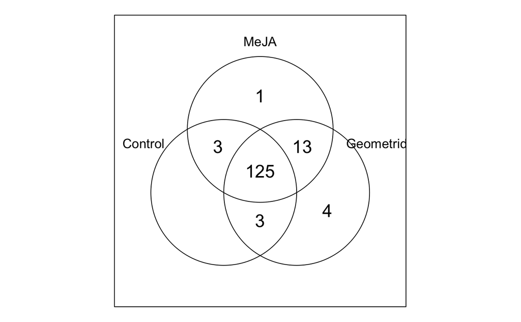

```r
x <- transmute(twister1, Control = con1 + con2 + con3 + con4,
               MeJA = meja1 + meja2 + meja3 + meja4,
               Geometrid = geo1 + geo2 + geo3)
x[x > 0] = 1
x$Compound <- twister1$Compound
x <- dplyr::select(x, Compound, everything())
venn(x[ , -1], cexil=1.5, cexsn=1.1)
```

```r
colSums(x[ , -1])
```

```
  Control      MeJA Geometrid
      131       142       145
```

```r
#unique to Geometrid:
Geometrid.unique <- subset(x, x$Geometrid != 0 & x$MeJA == 0 & x$Control == 0)
Geometrid.unique
```

| Compound | Control | MeJA | Geometrid |
| --- | --- | --- | --- |
| epi-α-Cadinol | 0 | 0 | 1 |
| 2-methyl-2-Buten-1-ol | 0 | 0 | 1 |
| p-Cymenene | 0 | 0 | 1 |
| γ-Decalactone | 0 | 0 | 1 |

```r
#unique to MeJA:
MeJA.unique <- subset(x, x$MeJA != 0 & x$Geometrid == 0 & x$Control == 0)
MeJA.unique
```

| Compound | Control | MeJA | Geometrid |
| --- | --- | --- | --- |
| 2,5-bis(1,1-dimethylethyl)-Phenol | 0 | 1 | 0 |

```r
#unique to Control
Control.unique <- subset(x, x$Control != 0 & x$Geometrid == 0 & x$MeJA == 0)
Control.unique
```

| Compound | Control | MeJA | Geometrid |
| --- | --- | --- | --- |

# PCA

```r
tea.pca2<-prcomp(twist2[ , -1], scale. = TRUE, center = TRUE)
summary(tea.pca2)
```

```
Importance of components%s:
                          PC1    PC2    PC3     PC4     PC5     PC6     PC7     PC8     PC9    PC10
Standard deviation     7.8965 5.0773 4.1811 3.50143 3.05850 2.50534 2.38775 1.99770 1.89174 1.49084
Proportion of Variance 0.4185 0.1730 0.1173 0.08228 0.06278 0.04213 0.03826 0.02678 0.02402 0.01492
Cumulative Proportion  0.4185 0.5915 0.7088 0.79111 0.85389 0.89602 0.93428 0.96107 0.98508 1.00000
                            PC11
Standard deviation     1.662e-15
Proportion of Variance 0.000e+00
Cumulative Proportion  1.000e+00
```

```r
#head(tea.pca2$rotation)
#screeplot(tea.pca2, type="lines")
```

```r
##my ggplot2 theme
multivar.theme <- theme_bw(base_size = 7, base_family = "Helvetica")+  #this changes the default text size and font
  theme(axis.title = element_text(size = 7),                      #this sets a different font size for the axis labels
        panel.border = element_rect(size = .5, color = "black"),   #change size= here to change border size
        panel.grid.major = element_blank(),                     #these two lines make the grid lines go away
        panel.grid.minor = element_blank(),
        legend.text = element_text(size = 6),                  #legend font size
        legend.background = element_rect(color = "black", size = 0.25),
        legend.key.size = unit(.75, "lines"))                    #spacing between text
        #legend.spacing = unit(.4, "lines"))                     #spacing between legends if > 1
```

[figure not shown]

```r
pca.correlations <- PC.cors(tea.pca2, as.data.frame(twist2[ , -1]), 2)
pca.correlations$PC1.r2 <- pca.correlations$PC1.corr.coefs^2
pca.correlations$PC2.r2 <- pca.correlations$PC2.corr.coefs^2
pca.correlations$PC1.p.corrected <- pca.correlations$PC1.p.values %>% p.adjust(method="fdr")
pca.correlations$PC2.p.corrected <- pca.correlations$PC2.p.values %>% p.adjust(method="fdr")

PC1.corr.sig <- pca.correlations %>% subset(PC1.p.corrected <= 0.05 & PC1.r2 >= 0.7,
                                            select = c(.Variables, PC1.corr.coefs, PC1.r2,
                                                       PC1.p.corrected))
PC2.corr.sig <- pca.correlations %>% subset(PC2.p.corrected <= 0.05 & PC2.r2 >= 0.7,
                                            select = c(.Variables, PC2.corr.coefs, PC2.r2,
                                                       PC2.p.corrected))
PC1.corr.sig[,-1] <- PC1.corr.sig[,-1] %>% signif(digits=3)
arrange(PC1.corr.sig, PC1.corr.coefs)

PC2.corr.sig[,-1] <- PC2.corr.sig[,-1] %>% signif(digits=3)
arrange(PC2.corr.sig, PC2.corr.coefs)

#xlsx package not working currently, so these don't work.
#write.xlsx(PC1.corr.sig, "Field Trial PCA compounds.xlsx", sheetName = "PC1", col.names = TRUE, row.names = FALSE)
#write.xlsx(PC2.corr.sig, "Field Trial PCA compounds.xlsx", sheetName = "PC2", col.names = TRUE, row.names = FALSE, append = TRUE)
```

[output not shown]

Nicole asks “Why is `γ-Terpinene` not highly correlated with PC1 when it is absent from control samples but present in both geometrid and MeJA treatments?”

Well, PC1 is the axis that explains the most variation in the data, so it’s likely that even though `γ-Terpinene` might be a good predictor of herbivory, it’s not super variable. Let’s look at what its loading is on PC1

```r
tea.pca2$rotation[rownames(tea.pca2$rotation) == "γ-Terpinene" , 1]
head(sort(tea.pca2$rotation[ ,1]))
#which PC has the greatest loading for gamma terpinene?
tea.pca2$rotation[rownames(tea.pca2$rotation) == "γ-Terpinene", ]
#PC3
head(sort(tea.pca2$rotation[ , 3]))
```

[output not shown]

It’s not very heavily weighting PC1 compared to other compounds. Maybe it is at very low concentrations when it is present. A bunch of zeros and a bunch of low concentration values would have very low variance.

```r
select(twist2, samples, `γ-Terpinene`)
```

[output not shown]

# ANOVA

```r
df <- data.frame(treatment = Treatment, PC1 = tea.pca2$x[ , 1], PC2 = tea.pca2$x[ , 2])
df
anova(lm(PC1 ~ treatment, data = df))
anova(lm(PC2 ~ treatment, data = df))
```

[output not shown]

An alternative method might be to use FDR corrected t-tests since it is very clear that PC1 separates the methods and PC2 separates the treatments

```r
important.PC1.data <- select(data, one_of(as.character(PC1.corr.sig$.Variables)))

sig.tests.PC1 <- vector(mode = "numeric", length = length(important.PC1.data))
for(i in 1:length(important.PC1.data)){
  test <- t.test(important.PC1.data[[i]] ~ data$Method)
  sig.tests.PC1[i] <- test$p.value
}

important.PC2.data <- select(data, one_of(as.character(PC2.corr.sig$.Variables)))

sig.tests.PC2 <- vector(mode = "numeric", length = length(important.PC2.data))
for(i in 1:length(important.PC2.data)){
  test <- t.test(important.PC2.data[[i]] ~ data$Treatment)
  sig.tests.PC2[i] <- test$p.value
}
```